# Hello, I’m healthiar!

Axel Luyten and Alberto Castro

axel.luyten@swisstph.ch & alberto.castrofernandez@swisstph.ch

2025-10-01

# Note

This presentation was part of an online *healthiar* workshop by [Swiss TPH](https://www.swisstph.ch/en/about/eph/environmental-exposures-and-health) held on 2025-10-01, which was recorded. [**The recording (45’) can be found here**](https://team.swisstph.ch/s/aN_wN5MUTAS3bwEkWvtvaQ): https://team.swisstph.ch/s/aN_wN5MUTAS3bwEkWvtvaQ

See the README file of the [*healthiar* GitHub repository for **information on how to install *healthiar* in RStudio**](https://github.com/SwissTPH/healthiar?tab=readme-ov-file#readme) and how to get started: https://github.com/SwissTPH/healthiar?tab=readme-ov-file#readme

Feedback is very welcome via [GitHub issues](https://github.com/SwissTPH/healthiar/issues) (preferred) or by email (addresses on first slide).

Disclaimer: the R package is still a work in progress - it could be that some of the exact code in this presentation will cede to work at some point, but the concepts behind them should stay the same.

The slides of this presentation can be found here: https://github.com/SwissTPH/healthiar/tree/master/varia/Workshops_and_demos/workshop

# Today

**First hour**

- Hello, I’m `healthiar`!
- `healthiar` function examples
- Outlook
- Q & A

**Break**

**Second hour**

- Hands-on mock case studies
- Q & A

# Hello, I’m `healthiar`!

## `healthiar` in numbers

- **1** purpose - to help you quantify and monetize the attributable burden of disease
- **3** dimensions - health, monetization, social aspects
- **20** functions
- **> 1000** calculation pathways
- **60000** (simple) assessments per second

## `healthiar` overview

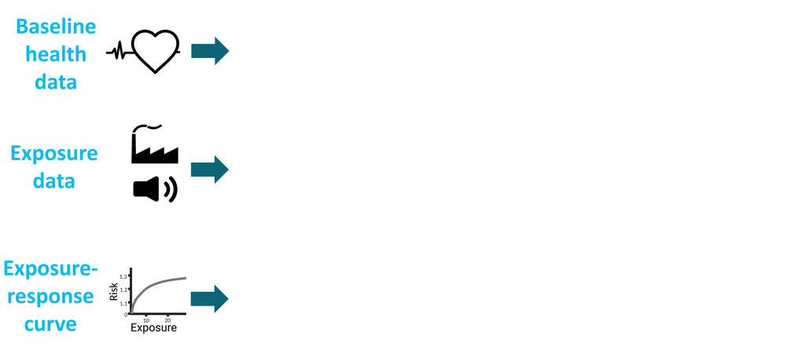

## `healthiar` overview

[figure not shown]

## `healthiar` overview

[figure not shown]

# Example: `attribute_health()` with RR

## Refresher - Burden of disease with relative risk

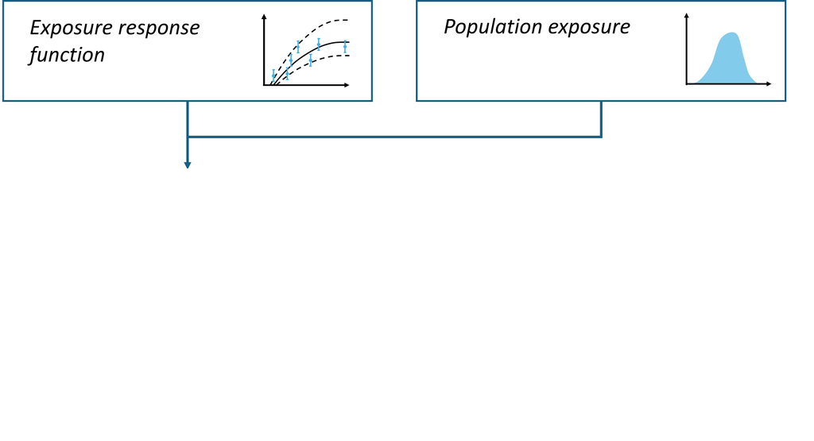

## Refresher - Burden of disease with relative risk

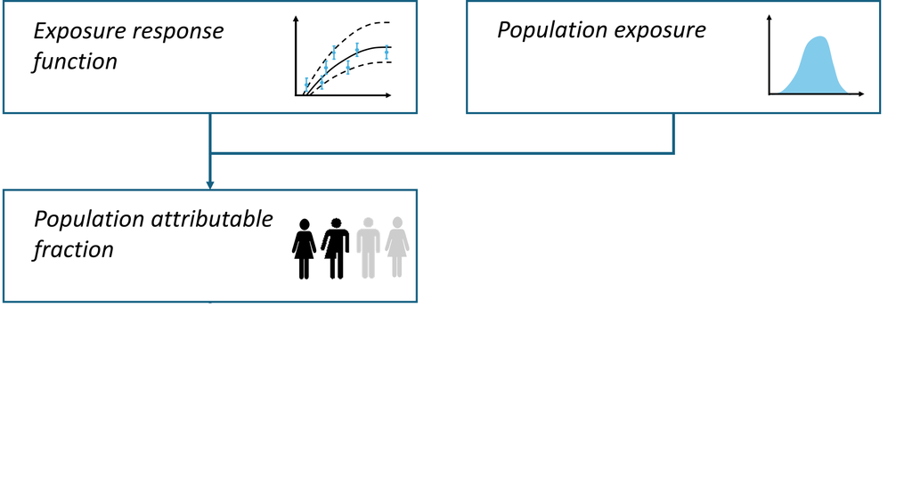

## Refresher - Burden of disease with relative risk

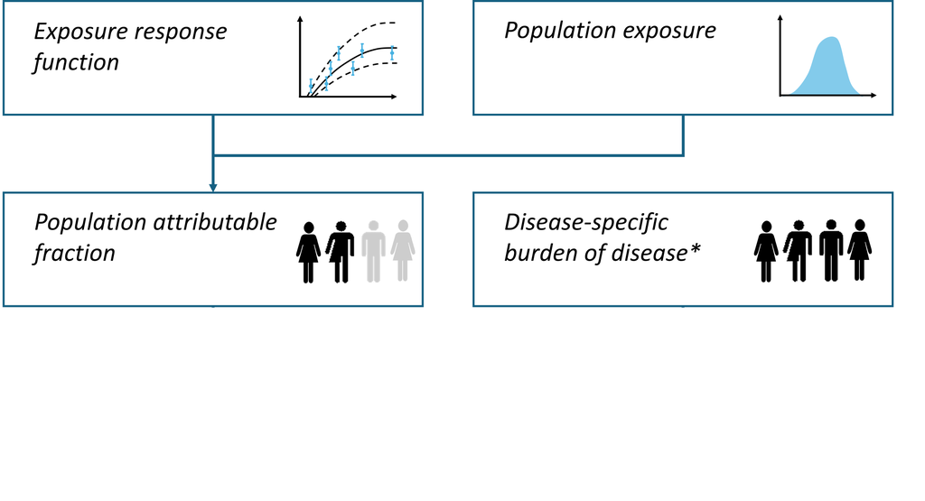

## Refresher - Burden of disease with relative risk

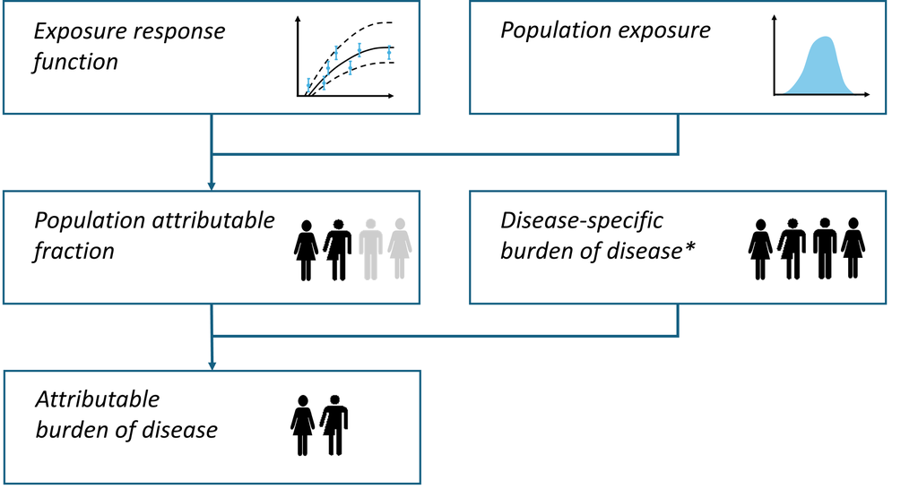

## `attribute_health()` with RR 1/3

Goal: attribute COPD cases to PM2.5 air pollution exposure

- Hard-coded input data
- Pre-loaded data

```r
results_pm_copd <- attribute_health(
  erf_shape = "log_linear", # erf = exposure-response function
  rr_central = 1.369,
  rr_increment = 10,  # μg / m^3
  exp_central = 8.85, # μg / m^3
  cutoff_central = 5, # μg / m^3
  bhd_central = 30747 # bhd = baseline health data (here: COPD incidence)
)
```

```r
results_pm_copd <- attribute_health(
  erf_shape = exdat_pm$erf_shape,
  rr_central = exdat_pm$relative_risk,
  rr_increment = exdat_pm$rr_increment,
  exp_central = exdat_pm$mean_concentration,
  cutoff_central = exdat_pm$cut_off_value,
  bhd_central = exdat_pm$incidence
)
```

## `attribute_health()` with RR 2/3

**Output structure**

`attribute_health()` outputs two lists (“folders”)

- `health_main` contains the main results
- `health_detailed` contains more detailed results and other assessment details in sub-lists (“sub-folders”)

## `attribute_health()` with RR 3/3

- With `$` operator
- View(…)
- By clicking

```r
results_pm_copd$health_main
```

| impact_rounded | impact | pop_fraction | erf_ci | rr | exp | bhd |
| --- | --- | --- | --- | --- | --- | --- |
| 3502 | 3501.962 | 0.1138961 | central | 1.369 | 8.85 | 30747 |

**Interpretation**

3’502 cases can be attributed to PM2.5 exposure.

```r
View(results_pm_copd$health_main)
```

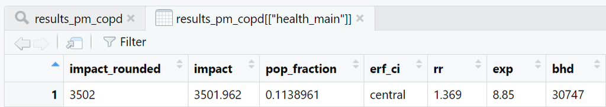

Go to the *Environment* tab in RStudio and click on a variable to “open” it

[figure not shown]

Then click on the little scroll symbol

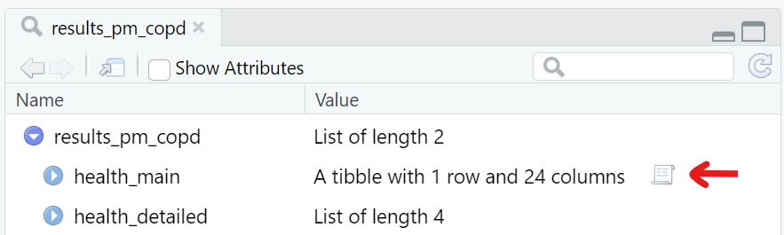

This opens a table of the results

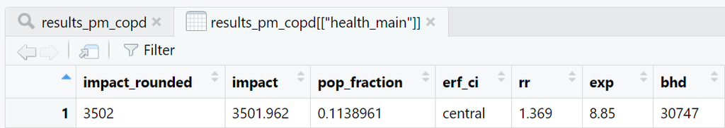

# Example: `compare()` two scenarios

## `compare()` two scenarios 1/2

Goal: compare attributable health impacts in two (policy) scenarios

1. Use `attribute_health()` to calculate burden of scenarios 1 & 2

```r
scenario_1 <- attribute_health(
  erf_shape = "log_linear",
  rr_central = 1.369,
  rr_increment = 10,
  exp_central = 8.85, # SCEN 1
  bhd_central = 30747
)
```

```r
scenario_2 <- attribute_health(
  erf_shape = "log_linear",
  rr_central = 1.369,
  rr_increment = 10,
  exp_central = 6, # SCEN 2
  bhd_central = 30747
)
```

2. Use `compare()` to compare scenarios 1 & 2

```r
results_comparison <- compare(
  output_attribute_scen_1 = scenario_1,
  output_attribute_scen_2 = scenario_2
)
```

## `compare()` two scenarios 2/2

```r
results_comparison$health_main
```

| impact | impact_rounded | impact_scen_1 | impact_scen_2 | bhd | exp_category | exp_length | exp_type | exp_scen_1 | exp_scen_2 |
| --- | --- | --- | --- | --- | --- | --- | --- | --- | --- |
| 2180.49 | 2180 | 7461.493 | 5281.003 | 30747 | 1 | 1 | population_weighted_mean | 8.85 | 6 |

**Interpretation**

By implementing the clean air policy we expect that 2’180 COPD cases can be avoided.

# Example: `attribute_health()` across multiple geographic units

## `attribute_health()` across multiple geographic units 1/3

Goal: attribute disease cases to PM2.5 exposure in multiple geographic units, such as municipalities, provinces, countries, …

```r
results_iteration <- attribute_health(
  geo_id_micro = c("Zürich", "Basel", "Geneva", "Ticino", "Jura"),
  geo_id_macro = c("German","German","French","Italian","French"),
  exp_central = c(11, 11, 10, 8, 7),
  bhd_central = c(4000, 2500, 3000, 1500, 500),
  erf_shape = "log_linear",
  rr_central = 1.369,
  rr_increment = 10,
  cutoff_central = 5
)
```

## `attribute_health()` across multiple geographic units 2/3

```r
results_iteration$health_main
```

| geo_id_macro | impact_rounded | erf_ci | exp_ci | bhd_ci |
| --- | --- | --- | --- | --- |
| German | 1116 | central | central | central |
| French | 466 | central | central | central |
| Italian | 135 | central | central | central |

**Tip**

The main results contain results aggregated by `geo_id_macro` (if available).

## `attribute_health()` across multiple geographic units 3/3

```r
results_iteration$health_detailed$results_raw
```

| geo_id_micro | geo_id_macro | impact_rounded |
| --- | --- | --- |
| Zürich | German | 687 |
| Basel | German | 429 |
| Geneva | French | 436 |
| Ticino | Italian | 135 |
| Jura | French | 30 |

**Tip**

Impact per geo unit specified in `geo_id_micro` is stored in the detailed results.

# Example: `summarize_uncertainty()`

## `summarize_uncertainty()` 1/3

If we add 95% confidence intervals to `attribute_health()` …

```r
results_pm_copd <- attribute_health(
  erf_shape = "log_linear",
  rr_central = 1.369, rr_lower = 1.114, rr_upper = 1.664,
  rr_increment = 10,
  exp_central = 8.85, exp_lower = 8, exp_upper = 10,
  cutoff_central = 5,
  bhd_central = 30747, bhd_lower = 28000, bhd_upper = 32000
)
```

… then the folder `health_detailed` contains all different uncertainty combinations:

```r
results_pm_copd$health_detailed$results_raw
```

| erf_ci | exp_ci | bhd_ci | impact_rounded | rr | exp | bhd |
| --- | --- | --- | --- | --- | --- | --- |
| central | central | central | 3502 | 1.369 | 8.85 | 30747 |
| lower | central | central | 1252 | 1.114 | 8.85 | 30747 |
| upper | central | central | 5474 | 1.664 | 8.85 | 30747 |
| central | central | lower | 3189 | 1.369 | 8.85 | 28000 |
| lower | central | lower | 1140 | 1.114 | 8.85 | 28000 |
| upper | central | lower | 4985 | 1.664 | 8.85 | 28000 |
| central | central | upper | 3645 | 1.369 | 8.85 | 32000 |
| lower | central | upper | 1303 | 1.114 | 8.85 | 32000 |
| upper | central | upper | 5697 | 1.664 | 8.85 | 32000 |
| central | lower | central | 2765 | 1.369 | 8.00 | 30747 |
| lower | lower | central | 980 | 1.114 | 8.00 | 30747 |
| upper | lower | central | 4356 | 1.664 | 8.00 | 30747 |
| central | lower | lower | 2518 | 1.369 | 8.00 | 28000 |
| lower | lower | lower | 892 | 1.114 | 8.00 | 28000 |
| upper | lower | lower | 3967 | 1.664 | 8.00 | 28000 |
| central | lower | upper | 2877 | 1.369 | 8.00 | 32000 |
| lower | lower | upper | 1020 | 1.114 | 8.00 | 32000 |
| upper | lower | upper | 4533 | 1.664 | 8.00 | 32000 |
| central | upper | central | 4468 | 1.369 | 10.00 | 30747 |
| lower | upper | central | 1616 | 1.114 | 10.00 | 30747 |
| upper | upper | central | 6911 | 1.664 | 10.00 | 30747 |
| central | upper | lower | 4069 | 1.369 | 10.00 | 28000 |
| lower | upper | lower | 1471 | 1.114 | 10.00 | 28000 |
| upper | upper | lower | 6294 | 1.664 | 10.00 | 28000 |
| central | upper | upper | 4651 | 1.369 | 10.00 | 32000 |
| lower | upper | upper | 1682 | 1.114 | 10.00 | 32000 |
| upper | upper | upper | 7193 | 1.664 | 10.00 | 32000 |

## `summarize_uncertainty()` 2/3

Goal: perform a Monte Carlo simulation to obtain summary uncertainty confidence intervals that combine uncertainty in different input data

Step 1: Use `attribute_health()` with uncertainty in ≥ 2 function arguments

```r
results <- attribute_health(
  erf_shape = "log_linear",
  rr_central = 1.369,
  rr_lower = 1.114,
  rr_upper = 1.664,
  rr_increment = 10,
  exp_central = 8.85,
  exp_lower = 8,
  exp_upper = 10,
  cutoff_central = 5,
  bhd_central = 30747,
  bhd_lower = 28000,
  bhd_upper = 32000)
```

Step 2: `summarize_uncertainty()` to obtain the confidence intervals

```r
results <-
  summarize_uncertainty(
    output_attribute = results,
    n_sim = 100
  )
```

## `summarize_uncertainty()` 3/3

```r
results$uncertainty_main
```

| impact_ci | impact | impact_rounded |
| --- | --- | --- |
| central_estimate | 3136.993 | 3137 |
| lower_estimate | 1537.385 | 1537 |
| upper_estimate | 5676.227 | 5676 |

# Example: `attribute_health()` with RR and user-defined ERF

## `attribute_health()` with RR and user-defined ERF 1/2

Goal: attribute COPD cases to air pollution exposure by applying a user-defined exposure response function (e.g. MR-BRT curves from Global Burden of Disease study)

- Any function of the form *intercept + a x c^1 + b x c^2 + …*
- Any other (non-linear) function of the `function` type, as obtained from e.g. `splinefun()` or `approxfun()`

```r
results_mr_brt <- attribute_health(
  exp_central = 8.85,
  bhd_central = 30747,
  erf_eq_central = splinefun(
    x = c(0, 5, 10, 15, 20, 25, 30, 50, 70, 90, 110),
    y = c(1.00, 1.04, 1.08, 1.12, 1.16, 1.20, 1.23, 1.35, 1.45, 1.53, 1.60),
    method = "natural")
)
```

## `attribute_health()` with RR and user-defined ERF 2/2

```r
results_mr_brt$health_main
```

| impact_rounded | impact | pop_fraction | erf_ci | rr_at_exp | exp | bhd |
| --- | --- | --- | --- | --- | --- | --- |
| 2033 | 2032.583 | 0.0661067 | central | 1.070786 | 8.85 | 30747 |

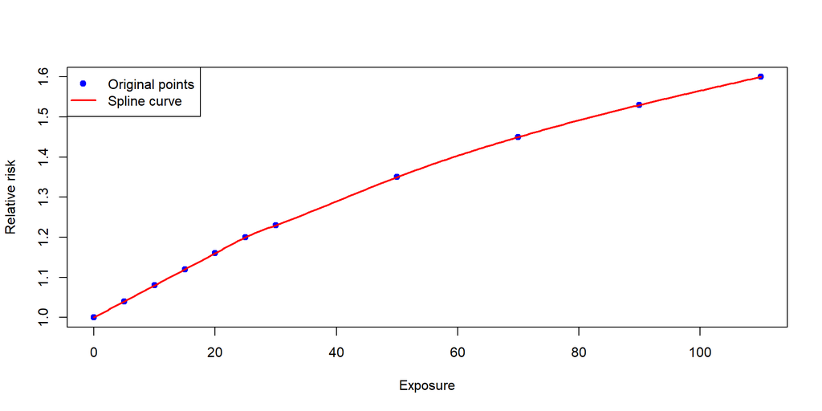

# Example: `attribute_health()` with RR and exposure distribution

## `attribute_health()` with RR and exposure distribution

Goal: attribute COPD cases to air pollution exposure categories

```r
results_pm_copd <- attribute_health(
  erf_shape = "log_linear",
  rr_central = 1.369,
  rr_increment = 10,
  exp_central = c(5, 6, 7, 8, 9, 10),
  prop_pop_exp = c(0.2, 0.1, 0.2, 0.3, 0.1, 0.1),
  cutoff_central = 5,
  bhd_central = 30747
)
```

```r
results_pm_copd$health_main
```

| impact_rounded | pop_fraction | exp | prop_pop_exp | rr_at_exp |
| --- | --- | --- | --- | --- |
| 2177 | 0.0707956 | 5, 6, 7, 8, 9, 10 | 0.2, 0.1, 0.2, 0.3, 0.1, 0.1 | 1, 1.03190649221009, 1.06483100866533, 1.09880603094837, 1.13386507701522, 1.1700427342623 |

# Example: `attribute_health()` with AR

## Refresher - Burden of disease with absolute risk

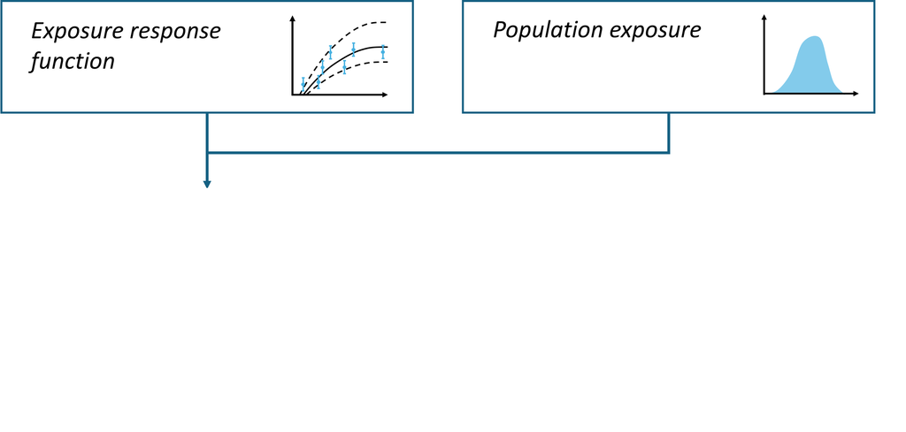

## Refresher - Burden of disease with absolute risk

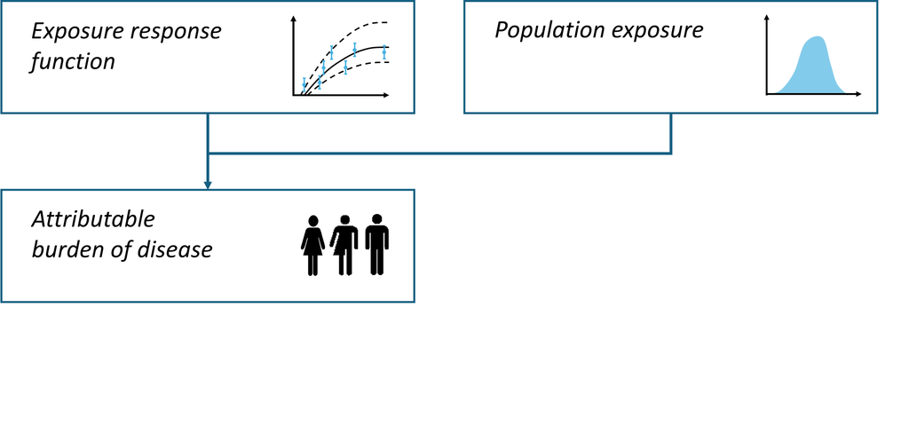

## `attribute_health()` with AR 1/2

Goal: attribute cases of high annoyance (HA) to noise exposure

| Exposure category | Exposure mean | Population exposed |
| --- | --- | --- |
| exp < 55 |  | 4’268’785 |
| 55 ≤ exp < 60 | 57.5 | 387’500 |
| 60 ≤ exp < 65 | 62.5 | 286’000 |
| 65 ≤ exp < 70 | 67.5 | 191’800 |
| 70 ≤ exp < 75 | 72.5 | 72’200 |
| 75 ≤ exp | 77.5 | 7’700 |

```r
results_noise_ha <- attribute_health(
  approach_risk = "absolute_risk",
  erf_eq_central = "78.9270-3.1162*c+0.0342*c^2",
  exp_central = c(57.5, 62.5, 67.5, 72.5, 77.5),
  pop_exp = c(387500, 286000, 191800, 72200, 7700),
)
```

## `attribute_health()` with AR 2/2

```r
results_noise_ha$health_main
```

| approach_risk | exp_category | impact |
| --- | --- | --- |
| absolute_risk | 1, 2, 3, 4, 5 | 174231.8 |

```r
results_noise_ha$health_detailed$results_raw
```

| exp_category | exp | pop_exp | impact |
| --- | --- | --- | --- |
| 1 | 57.5 | 387500 | 49674.594 |
| 2 | 62.5 | 286000 | 50788.595 |
| 3 | 67.5 | 191800 | 46813.105 |
| 4 | 72.5 | 72200 | 23657.232 |
| 5 | 77.5 | 7700 | 3298.314 |

# Other `healthiar` functions

## Other `healthiar` functions

- `attribute_lifetable()` for YLL
- `attribute_health()` for YLD (using the `dw` & `duration` arguments)
- `daly()` sums attributable YLL and YLD impacts
- `monetize()` monetizes (attributable) health impacts
- `cba()` performs a cost-benefit analysis (CBA)
- `multiexpose()` considers exposure to 2 exposures (e.g. two different air pollutants) at the same time to quantify the attributable health impacts
- `prepare_exposure()` calculates (population-weighted) mean exposure by combining spatial exposure and geographic units data
- `socialize()` determines burden attributable to differences in a social indicator
- `attribute_mod()` modifies an existing `attribute_health()` assessment
- `prepare_mdi()` creates the BEST-COST MDI (Multidimensional Deprivation Index)

# Outlook

## Outlook

- `healthiar` is publicly available on this [GitHub page](https://github.com/SwissTPH/healthiar)
- Package submitted to CRAN
- Python version coming out later in 2026
- `healthiar` might be expanded in the future (if funding available)

# Q & A

# Second hour programme

## Second hour programme

- Exercises in small groups (ca. 40 min)
- Presentation of solutions in plenum (ca. 10 min)
- Q & A (remaining time)

**Exercises** and **slides** from this presentation can be downloaded from [this folder on the *healthiar* GitHub page](https://github.com/SwissTPH/healthiar/tree/master/varia/Workshops_and_demos/workshop) (link also in the last email and in the Zoom chat).

**Install and load the `healthiar` R package** (code also found at the start of the exercises).

If asked to, please install or update dependencies.

```r
install.packages(c("remotes", "knitr", "rmarkdown"))
remotes::install_github(repo = "SwissTPH/healthiar", build_vignettes = TRUE)
library(healthiar)
```

Happy coding!

# Q & A

# Feedback

## Feedback

Please answer 3 short questions to provide your valuable feedback via [this short form](https://swisstph.wufoo.com/forms/s1k7txho0lrkpj1/) (link also in the last email and in the Zoom chat)

Also, any input via [GitHub issues](https://github.com/SwissTPH/healthiar/issues) is also welcome.

Or you can write to Alberto (alberto.castrofernandez@swisstph.ch) and Axel (axel.luyten@swisstph.ch).

# Appendix

## Addtional function examples

For additional function examples please see the function documentations and the package vignette.

The next slides will show you how to access them.

## `healthiar` in RStudio 1/3

[figure not shown]

Figure: Landing page of the `healthiar` package in RStudio, where you find the package vignettes and function documentation.

## `healthiar` in RStudio 2/3

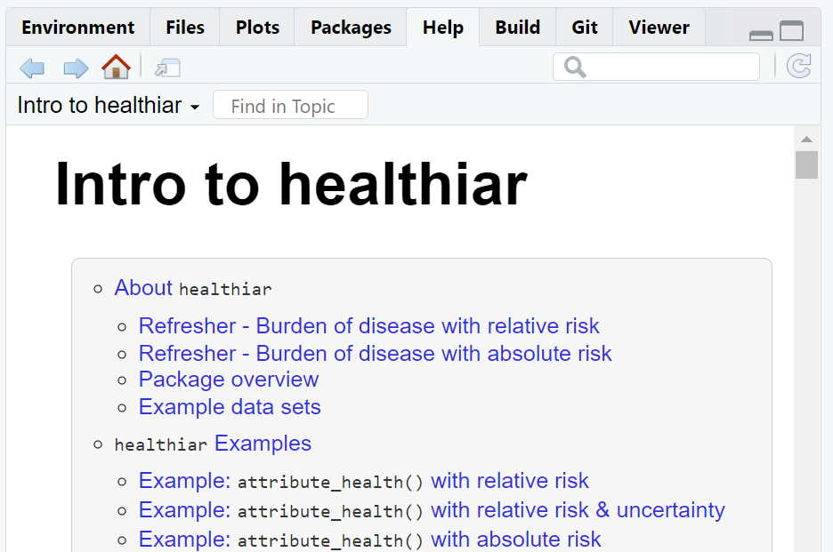

Figure: Intro to `healthiar` vignette (= detailed guide to the package)

## `healthiar` in RStudio 3/3

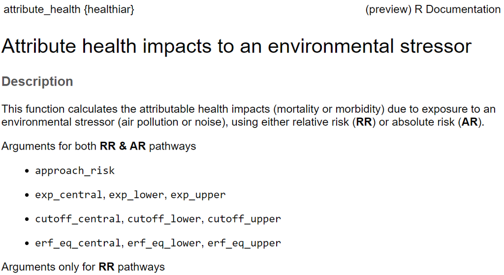

Figure: Help page of `attribute_health()`

## Export results

- Export as `.csv` file
- Save as `.Rdata` file
- Export to Excel (as `.xlsx` file)

```r
write.csv(x = results_pm_copd$health_main, file = "exported_results/results_pm_copd.csv")
```

```r
save(results_pm_copd, file = "exported_results/results_pm_copd.Rdata")
```

```r
write.xlsx(x = results_pm_copd$health_main, file = "exported_results/results_pm_copd.xlsx")
```

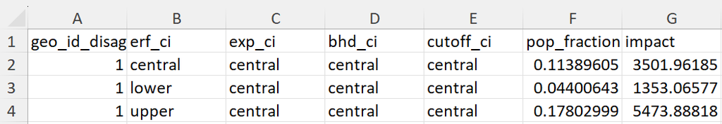

*Exported to .xlsx format*

## Visualize results

Visualization is out of scope of `healthiar`. You can visualize in

- R, e.g. with the `ggplot2` package ([online book by the creator](https://ggplot2-book.org/))
- Excel (export results first)
- Other tools